# Introducción a ggplot2

## Paso 2: Decirle qué estéticas va a considerar

Como comentamos arriba, **las estéticas** son los componentes que serán agregados en el gráfico. En otras palabras, los datos a graficar (*mapping*).

En este caso, vamos a decirle que considere que el eje x del gráfico represente *el salario inicial del trabajador* y el eje y *el salario actual*:

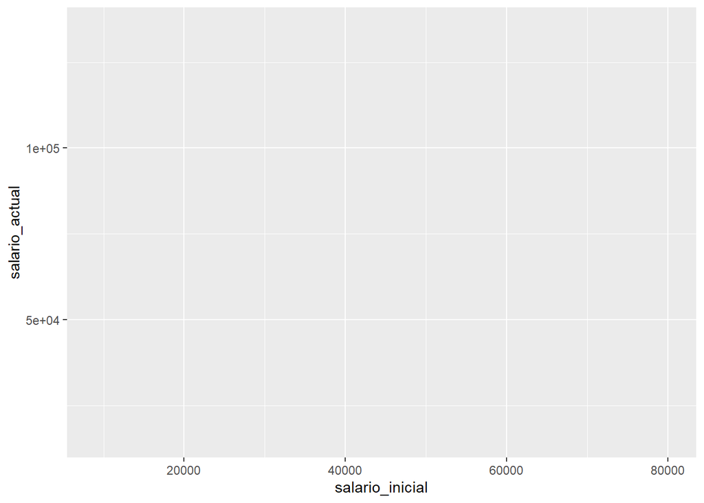

```r
ggplot(trabajadores, mapping = aes(x=salario_inicial, y= salario_actual))
```

Hasta el momento vemos que ya aparecen los ejes x e y pero aún no nos aparece ningún gráfico.

Ya detallamos la data, ya detallamos los ejes, ahora queda precisar qué gráfico queremos.

## Paso 3: Agregar capas

En este caso, al estar trabajando con dos numéricas podemos decirle al comando que nos muestre un gráfico de dispersión. Entonces, tenemos que agregar la capa necesaria, es decir: + geom_point()

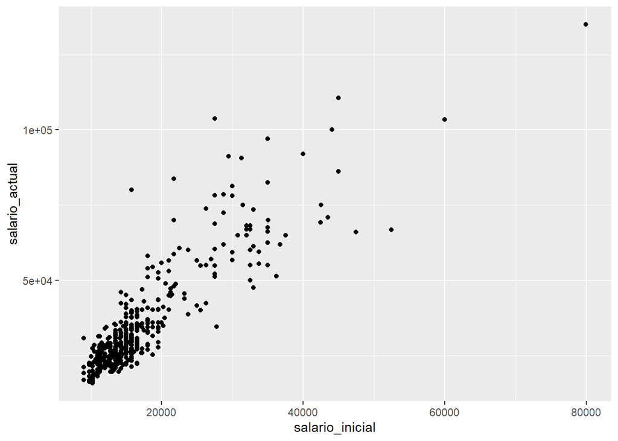

```r
ggplot(trabajadores, mapping = aes(x=salario_inicial, y= salario_actual)) + geom_point()
```

## Paso 4: Guardar el gráfico

Una vez tengamos el gráfico terminado podemos guardarlo como un archivo .png con el siguiente comando:

```r
ggsave("mi_grafico.png")
```